# A LUXURY FOR SOME, A NEED FOR ALL

The Water Gap

Author

Alessia Borlenghi

[figure not shown]

“Ensure availability and sustainable management of water and sanitation for all”  
by 2030, is the United Nations SDG 6.

Unfortunately, **reality is still so far** from the achievement of the universal access to safe water.

**1 in 4 people** worldwide still lacked access to safe water, in 2024.

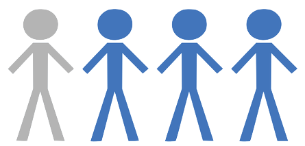

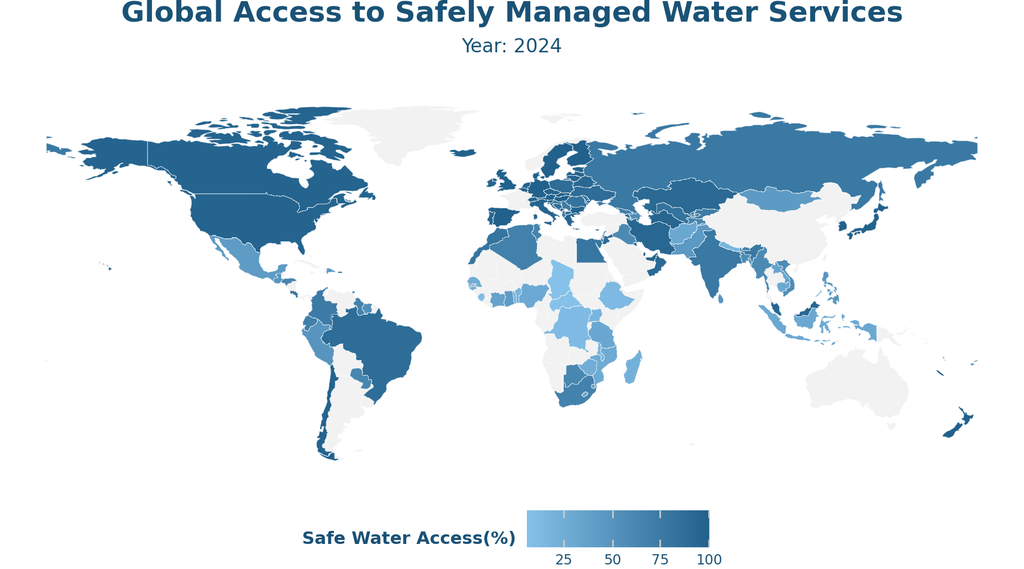

```python
import polars as pl
from plotnine import *
import geopandas as gpd

df_unicef = (
    pl.read_csv("/content/drive/MyDrive/UNICEF Data/unicef_indicator_1.csv")
    .filter(pl.col("time_period") == 2024)
    .join(
        pl.read_csv("/content/drive/MyDrive/UNICEF Data/unicef_metadata.csv"),
        on="alpha_3_code"
    )
)

df_unicef_pandas = df_unicef.to_pandas()

url = "https://naturalearth.s3.amazonaws.com/110m_cultural/ne_110m_admin_0_countries.zip"
world = gpd.read_file(url)
world = world[world['NAME'] != "Antarctica"]

world_final = world.merge(df_unicef_pandas, left_on="ISO_A3", right_on="alpha_3_code", how="left")

(
    ggplot(world_final)
    + geom_map(aes(fill='obs_value'), color="white", size=0.1)

    + scale_fill_gradient(
        low="#85c1e9",
        high="#21618c",
        na_value="#f2f2f2",
        name="Safe Water Access(%)"
    )

    + theme_void()
    + labs(
        title="Global Access to Safely Managed Water Services",
        subtitle="Year: 2024",
    )
    + theme(
        figure_size=(9, 5),
        plot_title=element_text(size=18, weight="bold", color="#1a5276", hjust=0.5),
        plot_subtitle=element_text(size=12, color="#1a5276", hjust=0.5, margin={'b': 20}),
        plot_caption=element_text(size=8, color="#1a5276"),
        legend_position="bottom",
        legend_title=element_text(color="#1a5276", weight="bold"),
        legend_text=element_text(color="#1a5276")
    )
)
```

**In 2024, the access to safely managed drinking water services remains an inaccessible luxury for millions**. The map highlights that, without a rapid and continuous expansion of infrastructures, the access to safe water will remain a benefit for high-income nations and out of reach for the most vulnerable populations, especially in Africa and Asia.

*Safe water* is the foundation of child survival and human development but it’s still a *geographic privilege* rather than a universal right.

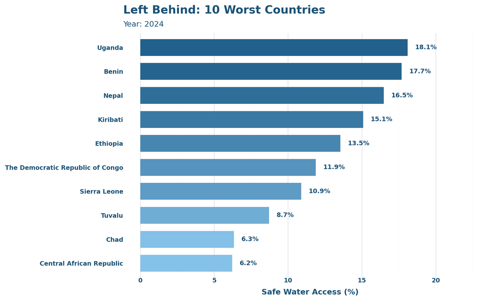

```python
import polars as pl
from plotnine import *

df_water = pl.read_csv("/content/drive/MyDrive/UNICEF Data/unicef_indicator_1.csv")

df_bar = (
    df_water
    .filter(pl.col("time_period") == 2024)
    .with_columns(
        pl.when(pl.col("country").str.contains("Congo"))
        .then(pl.lit("The Democratic Republic of Congo"))
        .otherwise(pl.col("country"))
        .alias("country")
    )
    .unique("country")
    .sort("obs_value")
    .head(10)
    .with_columns(
        pl.format("{}%", pl.col("obs_value").round(1)).alias("lbl")
    )
)

(
    ggplot(df_bar, aes(x='reorder(country, obs_value)', y='obs_value', fill='obs_value'))
    + geom_col(show_legend=False, width=0.7)
    + geom_text(aes(label='lbl'), ha='left', nudge_y=0.5, size=9, fontweight="bold", color="#1a5276")
    + coord_flip()
    + scale_fill_gradient(low="#85c1e9", high="#21618c")
    + labs(title="Left Behind: 10 Worst Countries", subtitle="Year: 2024", x="", y="Safe Water Access (%)")
    + theme_minimal()
    + theme(
        figure_size=(10, 6),
        plot_title=element_text(weight="bold", size=16, color="#1a5276"),
        plot_subtitle=element_text(color="#1a5276"),
        axis_text=element_text(color="#1a5276", weight="bold"),
        axis_title=element_text(color="#1a5276", weight="bold"),
        panel_grid_major_y=element_blank()
    )
    + scale_y_continuous(limits=(0, 23), breaks=[0, 5, 10, 15, 20])
)
```

The bar chart highlights the dramatic situation facing the 10 countries with the lowest water coverage worldwide in 2024.  
A natural question arises: *is the access to safe water directly correlated to the country’s wealth*?

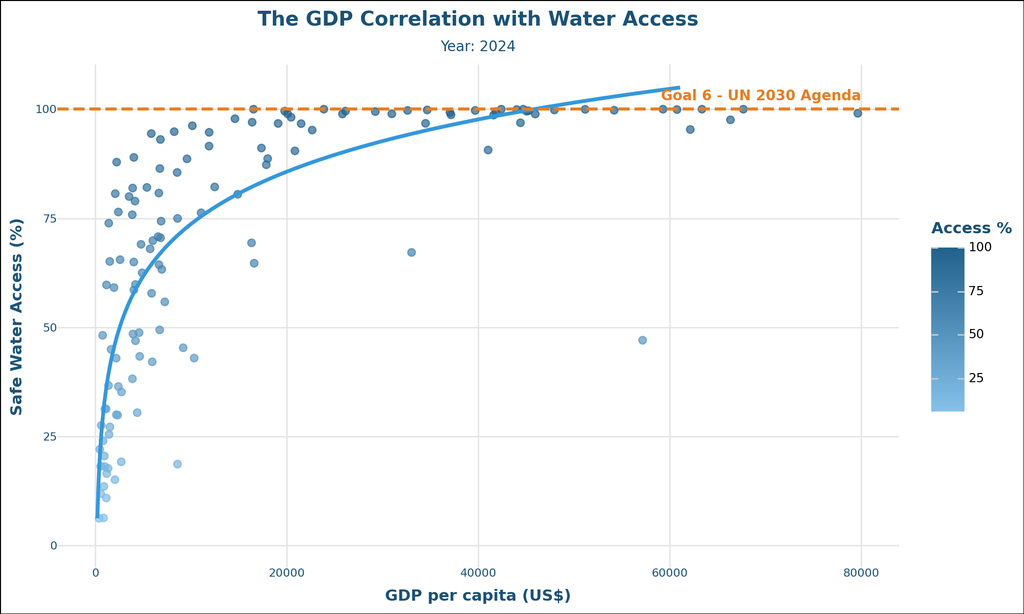

```python
import polars as pl
from plotnine import *

df_plot = (
    df_water.filter(pl.col("time_period") == 2024)
    .join(
        df_metadata.filter(pl.col("year") == 2024),
        on="alpha_3_code",
        how="inner"
    )
    .filter(~pl.col("alpha_3_code").is_in(["MCO", "LUX"]))
    .filter(pl.col("GDP per capita (constant 2015 US$)") > 0)
    .drop_nulls(subset=["GDP per capita (constant 2015 US$)", "obs_value"])
)

stats = (
    df_plot
    .select([
        pl.col("GDP per capita (constant 2015 US$)").log().alias("log_x"),
        pl.col("obs_value").alias("y")
    ])
    .select([
        (pl.cov("log_x", "y") / pl.var("log_x")).alias("A"),
        pl.col("log_x").mean().alias("mean_log_x"),
        pl.col("y").mean().alias("mean_y")
    ])
    .with_columns(
        B = pl.col("mean_y") - pl.col("A") * pl.col("mean_log_x")
    )
)

A_coeff = stats["A"][0]
B_coeff = stats["B"][0]

df_trend = (
    pl.DataFrame({
        "x_line": pl.arange(1, 80000, step=100, eager=True)
    })
    .with_columns(

        y_line = (A_coeff * pl.col("x_line").log() + B_coeff)
    )
)

scatter_final = (
    ggplot(df_plot, aes(x="GDP per capita (constant 2015 US$)", y="obs_value"))

    + geom_point(aes(color="obs_value"), alpha=0.7, size=2.5)
    + scale_color_gradient(low="#85c1e9", high="#21618c")

    + geom_line(data=df_trend, mapping=aes(x="x_line", y="y_line"),
                color="#3498db", size=1.5, inherit_aes=False)

    + geom_hline(yintercept=100, linetype="dashed", color="#E67E22", size=1.2)
    + annotate("text", x=80000, y=103, label="Goal 6 - UN 2030 Agenda",
               color="#E67E22", fontweight="bold", ha="right", size=10)

    + labs(
        title="The GDP Correlation with Water Access",
        subtitle="Year: 2024",
        x="GDP per capita (US$)",
        y="Safe Water Access (%)",
        color="Access %"
    )

    + theme_minimal()
    + theme(
        figure_size=(10, 6),
        panel_background=element_rect(fill="white"),
        plot_background=element_rect(fill="white"),

        plot_title=element_text(size=14, weight="bold", ha="center", color="#1a5276"),
        plot_subtitle=element_text(size=10, ha="center", color="#1a5276"),
        axis_title=element_text(color="#1a5276", weight="bold"),
        axis_text=element_text(size=8, color="#1a5276"),
        legend_title=element_text(color="#1a5276", weight="bold"),
        legend_position="right",
        panel_grid_minor=element_blank()
    )
    + scale_y_continuous(limits=(0, 105), breaks=[0, 25, 50, 75, 100])
    + scale_x_continuous(limits=(0, 80000))
)

scatter_final
```

*The x-axis has been reduced to improve the readability and comparison between the majorty of nations. The high-income outliers Monaco and Luxembourg have been excluded to prevent data compression.*

There is a *positive relationship between GDP and access to safe water*. While wealthy nations have reached universal access, the high density of countries in the lower-left quadrant highlights that *low-income countries, despite some improvements in the last two decades, are still struggling to guarantee appropriate hydric infrastructures*.  
Children, people living in unprivileged contexts, rural communities and ethnic minorities are subjected to major disparities.

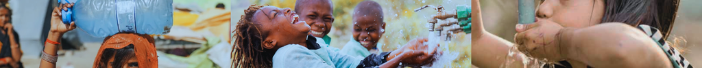

**A World in Motion: Progress Towards Equity**

The World is not standing still. While significant disparities remain globally, focused investments and political will can bridge the gap and achieve the UN 2030 Objective of universal access to safe water.

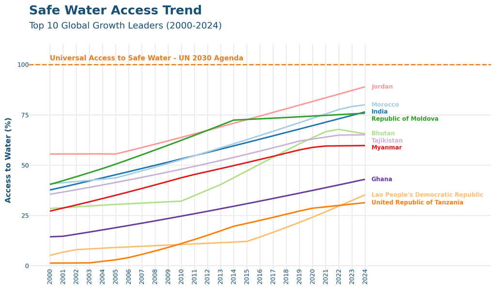

```python
import polars as pl
from plotnine import *

df_clean = (
    df_water
    .drop_nulls(subset=["time_period", "obs_value"])
    .with_columns(
        pl.when(pl.col("country").str.to_lowercase().str.contains("tanzania"))
        .then(pl.lit("United Republic of Tanzania"))
        .when(pl.col("country").str.to_lowercase().str.contains("moldova"))
        .then(pl.lit("Republic of Moldova"))
        .when(pl.col("country").str.to_lowercase().str.contains("congo"))
        .then(pl.lit("The Democratic Republic of Congo"))
        .otherwise(pl.col("country"))
        .alias("country")
    )
)

growth_df = (
    df_clean
    .sort(["country", "time_period"])
    .group_by("country")
    .agg([
        pl.col("obs_value").first().alias("val_start"),
        pl.col("obs_value").last().alias("val_end"),
        pl.col("time_period").last().alias("year_end")
    ])
    .with_columns(
        (pl.col("val_end") - pl.col("val_start")).alias("growth")
    )
    .sort("growth", descending=True)
    .head(10)
)

top_list = growth_df["country"].to_list()

df_labels = growth_df.select(["country", "year_end", "val_end"]).sort("val_end", descending=True)
y_vals = df_labels["val_end"].to_list()
y_pos = [y_vals[0]]

for i in range(1, len(y_vals)):
    gap = 3.5
    new_y = y_pos[i-1] - gap if y_pos[i-1] - y_vals[i] < gap else y_vals[i]
    y_pos.append(new_y)

df_labels = df_labels.with_columns(pl.Series("y_pos", y_pos))

df_line = df_clean.filter(pl.col("country").is_in(top_list))

colors = ["#A6CEE3", "#1F78B4", "#B2DF8A", "#33A02C", "#FB9A99",
          "#E31A1C", "#FDBF6F", "#FF7F00", "#CAB2D6", "#6A3D9A"]
color_map = dict(zip(top_list, colors))

min_x = df_line["time_period"].min()
max_x = df_line["time_period"].max()

(
    ggplot(df_line, aes(x="time_period", y="obs_value", color="country", group="country"))
    + geom_line(size=1.2)

    + geom_text(
        data=df_labels,
        mapping=aes(x="year_end", y="y_pos", label="country", color="country"),
        ha="left",
        nudge_x=0.5,
        size=8.5,
        fontweight="bold",
        inherit_aes=False
    )

    + geom_hline(yintercept=100, linetype="dashed", color="#E67E22", size=1)
    + annotate("text", x=min_x, y=103, label="Universal Access to Safe Water - UN 2030 Agenda",
               color="#E67E22", ha="left", fontweight="bold", size=10)

    + scale_color_manual(values=color_map, guide=None)
    + labs(
        title="Safe Water Access Trend",
        subtitle="Top 10 Global Growth Leaders (2000-2024)",
        x="", y="Access to Water (%)"
    )

    + theme_minimal()
    + theme(
        figure_size=(10, 6),
        plot_title=element_text(size=18, weight="bold", color="#1a5276"),
        plot_subtitle=element_text(size=13, color="#1a5276", margin={'b': 20}),
        axis_title=element_text(color="#1a5276", weight="bold"),
        axis_text_x=element_text(rotation=90, vjust=0.5, size=9, color="#1a5276"),
        axis_text_y=element_text(size=9, color="#1a5276"),
        panel_grid_minor=element_blank()
    )
    + scale_y_continuous(limits=(0, 105), breaks=[0, 25, 50, 75, 100])
    + scale_x_continuous(
        limits=(min_x, max_x + 8),
        breaks=range(int(min_x), int(max_x) + 1, 1)
    )
)
```

*These ten countries have been identified as the global leaders in progress, showing the highest absolute growth in access to safely managed water services since 2000.*

The evidence is clear: *progress is possible*.  
Safe water must not be a matter of geography, but a *universal human right*.

**THE GOAL IS SET, THE TIME TO ACT IS NOW.**

[figure not shown]